# Oxazolidinones

## Oxazolidinones

**Russell E. Lewis**  
Associate Professor of Infectious Diseases (MEDS-10/B)

russelledward.lewis@unipd.it  
[https://github.com/Russlewisbo](https://github.com/Russlewisbo/ESCMID_2022_talk)  
Slides and course materials: [www.idpadova.com](https://padovaid.com/)

## Learning objectives

- Describe the **chemical features** that distinguish linezolid and tedizolid and the structural basis for activity against *cfr*-carrying strains
- Explain the **mechanism of action** and why oxazolidinones avoid cross-resistance with β-lactams, glycopeptides, daptomycin and quinupristin-dalfopristin
- Recognize the **four major resistance mechanisms** and their clinical implications
- Apply **PK/PD** principles, dosing and TDM thresholds in adults, including special populations
- Choose oxazolidinones appropriately in **MRSA, VRE, MDR-TB, and Nocardia** infections
- Anticipate, monitor for, and manage **hematologic, neurologic, metabolic, and serotonergic toxicities**

# Overview and chemistry

## A fully synthetic antibiotic class

- Oxazolidinones are prepared entirely by **organic synthesis** — no fermentation product
- 1978: DuPont patents 5-(halomethyl)-3-aryl-2-oxazolidinones with activity against **plant pathogens**
- Further optimization → first agents with activity against **human pathogens**

(Slee et al., 1987)

## Two FDA/EMA-approved agents

| Drug | Trade name | FDA approval |
| --- | --- | --- |
| **Linezolid** | Zyvox | April 2000 |
| **Tedizolid** (phosphate) | Sivextro | June 2014 |

- Investigational agents: **sutezolid, radezolid, delpazolid, contezolid**
- No drug-class cross-resistance with β-lactams, vancomycin, daptomycin, or quinupristin-dalfopristin

Note that tedizolid is a prodrug — phosphate ester cleaved by plasma phosphatases. Contezolid (MRX-I) is approved in China for ABSSSI; the pipeline is moving on TB indications.

## Basic oxazolidinone scaffold

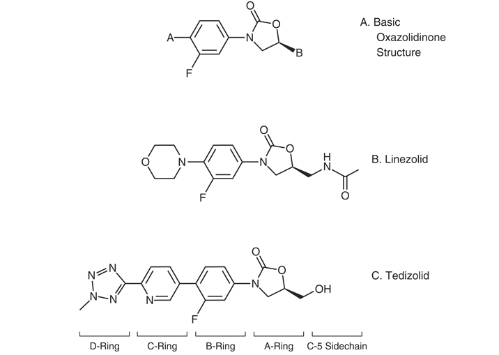

- Core five-membered **2-oxazolidinone ring** (the “A-ring”)
- **C5 modification** of the A-ring and **N-aryl B-ring** are essential for antibacterial activity
- **Fluorination of the B-ring** further increases potency

The C5 side chain is the structural feature that diverges between linezolid and tedizolid — and is the most important thing to remember when explaining why tedizolid keeps activity against cfr-carrying strains (Rybak and Roberts, 2015).

## Linezolid — structural features

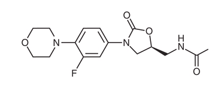

- C5 **acetamide** side chain on the A-ring
- N-aryl B-ring with **single fluorine**
- Single morpholine D-substituent
- Sufficient for activity against typical Gram-positive targets

(Rybak and Roberts, 2015)

## Tedizolid — engineered for breadth

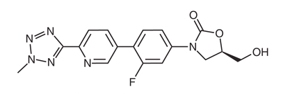

- C5 **hydroxymethyl** group replaces acetamide → preserves activity against *cfr*-carrying strains
- Added **pyridine (C-ring) and tetrazole (D-ring)** moieties → lower MICs
- Administered as the **phosphate prodrug** (Sivextro)

The hydroxymethyl group is the specific modification that defeats Cfr methylation of A2503. The tetrazole/pyridine contribute to overall MIC reduction but are not the cfr-defeating feature (Locke et al., 2010; Rybak and Roberts, 2015).

# Mechanism of action

## Where do oxazolidinones bind?

[figure not shown]

Oxazolidinones block one of the earliest steps in protein synthesis. Chloramphenicol and lincomycin bind in overlapping sites — useful for explaining mechanistic competition observed in vitro (Colca et al., 2003; Moellering, 2003).

## Bacteriostatic — and why that’s fine

- Generally **bacteriostatic** against staphylococci and enterococci; modestly bactericidal against streptococci
- “Static vs cidal” distinction may be **clinically overrated** — systematic reviews have found no consistent outcome difference
- Don’t withhold linezolid in *S. aureus* bacteremia on cidal-vs-static grounds alone

(Wald-Dickler et al., 2018).

# Spectrum of activity

## Aerobic Gram-positive activity

| Organism | Linezolid MIC₉₀ (μg/mL) | Tedizolid MIC₉₀ (μg/mL) |
| --- | --- | --- |
| MSSA | 2 | 0.25 |
| MRSA | 2 | 0.25 |
| *S. agalactiae* | 2 | 0.25 |
| *S. anginosus* gp | 1 | 0.25 |
| *S. pyogenes* | 2 | 0.25 |
| *E. faecalis* | 2 | 0.25 |
| *E. faecalis* (LZD-NS) | 8 | 1 |
| *E. faecium* | 2 | 0.5 |

(Carvalhaes et al., 2022)

## Tedizolid is more potent in vitro — but…

(Clinical and Laboratory Standards Institute, 2022; European Committee on Antimicrobial Susceptibility Testing, 2022)

## Mycobacteria

- Excellent activity against **MDR- and XDR-***M. tuberculosis*
  - Linezolid MIC range: **0.125–2 μg/mL**
  - Tedizolid MIC range: **0.125–0.5 μg/mL**
- Active against rapid growers (*M. abscessus* spp., *M. massiliense*) and **slow-grower *M. kansasii***
- Higher MICs for *M. avium* / *M. intracellulare*

(Aono et al., 2022; Yang et al., 2012)

## Nocardia and other higher-order bacteria

- Linezolid: **virtually 100% in vitro susceptibility** across *Nocardia* spp.
  - MIC₉₀ 1–4 μg/mL
- Tedizolid: lower MICs than linezolid for most *Nocardia* spp.
  - Comparable to linezolid for *N. nova* **complex** and *N. brasiliensis*
- Variable activity vs. actinomycetes; *Corynebacterium*, *Listeria*, *Bacillus*, *Erysipelothrix*, *Rhodococcus equi*, *Leuconostoc*, *Pediococcus* — case-by-case

(Brown-Elliott and Wallace, 2017; Larruskain et al., 2011)

## Where oxazolidinones do NOT shine

- **Aerobic Gram-negatives:** limited
- Incomplete coverage of respiratory pathogens *H. influenzae* and *Moraxella catarrhalis*
- **Anaerobes:** decent activity against both Gram-positive and Gram-negative anaerobes
  - *Clostridium* spp., *Bacteroides* spp.

(Biedenbach and Jones, 2001; Goldstein et al., 1999)

This is why linezolid is not used as empirical monotherapy in nosocomial pneumonia or intra-abdominal infection without a Gram-negative companion.

# Resistance

## The headline numbers

- Linezolid resistance **reported pre-marketing** (Compassionate Use Program, VRE)
- ~25 years post-launch, resistance still **<1%** of clinical isolates
- Tedizolid resistance **rarer** than linezolid resistance over a 5-year surveillance
- **Enterococci > staphylococci** for resistance frequency

(Birmingham et al., 2003; Mendes et al., 2018)

## Risk factors for resistance

- **Prior linezolid exposure**
- **Prolonged therapy** (weeks to months)
- Horizontal spread within ICUs and long-term care facilities
- Stewardship implication: limit duration, monitor when prolonged use unavoidable

(Bonilla et al., 2010; Pogue et al., 2007)

## Mechanism 1 — 23S rRNA mutations

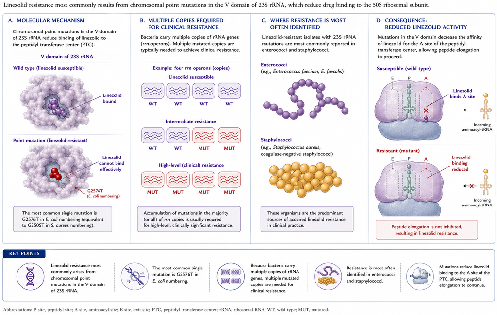

(Long and Vester, 2012)

## Mechanism 2 — ribosomal protein mutations

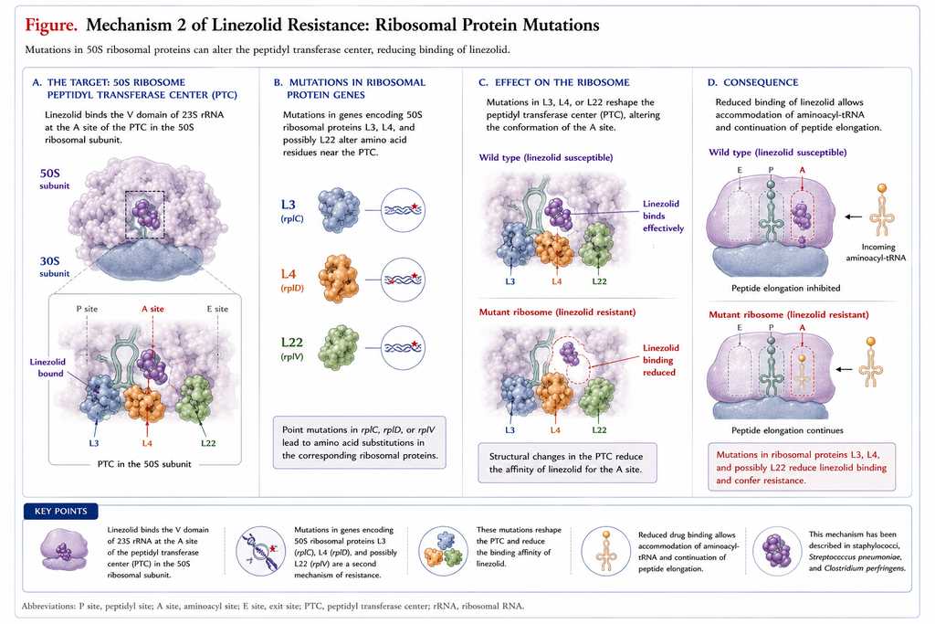

(Brenciani et al., 2022; Hölzel et al., 2010)

## Mechanism 3 — *cfr* methyltransferase

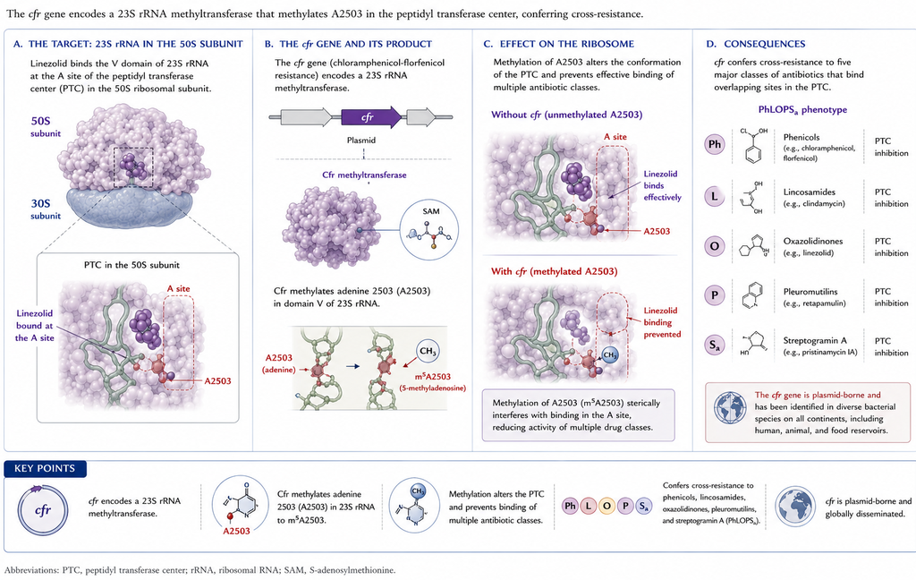

## Mechanism 4 — optrA and poxtA

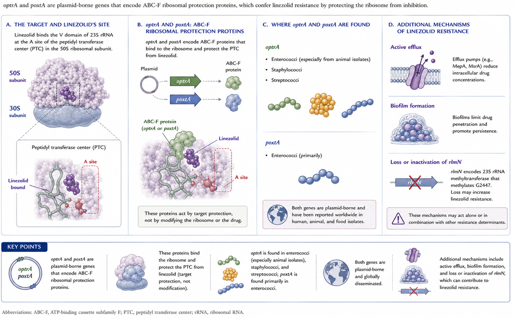

(Bender et al., 2018; Wang et al., 2015)

## Tedizolid vs. linezolid-resistant strains

- Tedizolid retains activity against many *cfr*-positive strains of *S. aureus*, CoNS, and enterococci
- Activity **lost** when *cfr* coexists with chromosomal ribosomal mutations
- **Practical message:** test before assuming susceptibility in known LZD-R isolates

(Locke et al., 2010)

# Pharmacology — linezolid

## Linezolid — dosing fundamentals

- **Adults / adolescents:** 600 mg PO or IV every 12 hours
- **Uncomplicated SSTI in adults:** 400 mg every 12 hours
- **Pediatric (birth–11 y):** 10 mg/kg every 8 hours (every 12 h for uncomplicated SSTI in children 5–11 y)
- **Bioavailability ~100%** — oral and IV interchangeable

(Pharmacia and Upjohn Company, 2021)

## Linezolid — distribution

- Plasma protein binding: **31%**
- Excellent penetration into **lung (ELF, alveolar macrophages)** and **skin and soft tissue**
- **CSF**: trough <0.2–7.0 μg/mL; peaks 3.1–12.5 μg/mL in meningitis; **CSF/plasma ratio 0.77–1.0**
- **Bone and joint penetration variable** — case-by-case

(Luque et al., 2014; Villani et al., 2002)

## Linezolid — metabolism and clearance

(Obach, 2022)

## Linezolid — PK/PD targets

- Driver of efficacy: **f<sub>T > MIC</sub> ≈ 85%** and **AUC₀₋₂₄/MIC 80–120**
- **High** **inter-individual variability** can compromise targets at standard dose
- **At-risk populations:**
  - Overexposure: renal dysfunction, older age, hepatic failure, low body weight
  - Under-exposure: augmented renal clearance, younger age, obesity
  - Both: critical illness

(Roger et al., 2018)

## Linezolid — when to consider TDM

- Trough **C<sub>min</sub> 2–7 mg/L** suggested for Gram-positive infection
- **C<sub>min</sub> <2 mg/L** proposed for *M. tuberculosis* (MICs lower)
- **C<sub>min</sub> >7.5–22.1 mg/L** → hematologic toxicity risk rises
- Strongest case for TDM: critically ill, **prolonged therapy**, renal dysfunction, drug interactions

(Pea et al., 2012; Rao et al., 2020)

## Linezolid — drug interactions (PK)

- **Rifampin** → ↓ AUC ~32% (P-gp induction?)
- **Levothyroxine** → ↓ linezolid concentrations
- **Clarithromycin** → ↑ linezolid AUC >3-fold
- **Amlodipine, amiodarone, omeprazole, warfarin** → linezolid overexposure reports
- Linezolid likely a **P-glycoprotein substrate**

(Bolhuis et al., 2010; Gandelman et al., 2011)

# Pharmacology — tedizolid

## Tedizolid — the prodrug story

- **Tedizolid phosphate** → cleaved by plasma phosphatases → active tedizolid
- **Bioavailability ~91%** — no dose adjustment IV vs. PO
- **200 mg once daily** PO or IV (adults and pediatric ≥ 12 y)
- **Half-life ~12 hours** supports once-daily dosing
- Oral product taken **without regard to meals**

(Merck & Co., Inc., 2021)

## Tedizolid — distribution and metabolism

(Iqbal et al., 2022)

## Tedizolid — special PK/PD caveats

- Free **AUC/MIC ratio** best predicts efficacy in murine models
- **Markedly reduced antistaphylococcal activity in granulocytopenic mice** — concerning signal
- Less pronounced effect in *S. pneumoniae* lung models
- **Product label cautions against use in neutropenic patients** — sparse human data

(Drusano et al., 2011; Xiao et al., 2019)

## Tedizolid — drug interactions

- Negligible CYP450 interaction
- **Inhibits intestinal BCRP** → ↑ serum levels of rosuvastatin, methotrexate
- **Weak, reversible MAOI** activity in vitro — less risk than linezolid but not zero
- Four post-marketing serotonin syndrome reports to FAERS

(Flanagan et al., 2015; Merck & Co., Inc., 2021)

# Clinical use

## FDA-approved indications — linezolid

- **Nosocomial pneumonia** (MRSA/MSSA, *S. pneumoniae*)
- **Community-acquired pneumonia** (*S. pneumoniae* including bacteremic; MSSA)
- **Complicated SSTI** (including diabetic foot, *without* osteomyelitis)
- **Uncomplicated SSTI** (MSSA, *S. pyogenes*)
- **VRE *E. faecium*** infections (including bacteremia)

(Pharmacia and Upjohn Company, 2021)

## FDA-approved indications — tedizolid

- **Acute bacterial skin and skin-structure infection (ABSSSI)** in adults and **pediatric patients ≥ 12 years**
- Susceptible Gram-positive pathogens:
  - *S. aureus* (MRSA/MSSA), *S. pyogenes*, *S. agalactiae*, *S. anginosus* group, *E. faecalis*

(Merck & Co., Inc., 2021)

## MRSA SSTI — linezolid vs vancomycin

- **Cochrane review** (9 RCTs): linezolid superior to vancomycin for clinical and microbiologic cure; shorter LOS, lower cost
- Superiority observed in **adults** but not in <18 y
- Recent **network meta-analysis**: linezolid superior to vancomycin; comparable to dapto, ceftaroline, telavancin, tigecycline, tedizolid

(Feng et al., 2021; Yue et al., 2016)

## MRSA nosocomial pneumonia — the Wunderink saga

- Pooled analysis of 2 RCTs (Wunderink 2003): linezolid + aztreonam ≈ vanc + aztreonam **overall**; subgroup analysis suggested superior survival in MRSA
- **Subgroup analysis criticized by FDA** (Powers, 2004)
- Subsequent **ZEPHyR trial** (Wunderink 2012): higher clinical success with linezolid, **no 60-day mortality difference**; questioned by under-dosed vancomycin arm

(Wunderink et al., 2012, 2003)

## MRSA pneumonia — meta-analytic verdict

- Pooled RCT data: **no difference** in clinical or microbiologic efficacy or all-cause mortality
- **Nephrotoxicity higher** with vancomycin — robust signal
- Practical message: **either is acceptable**; choose by toxicity profile, route, and TDM feasibility

(Kalil et al., 2013)

## *S. aureus* bacteremia — linezolid’s evolving role

- Effective for **MSSA and MRSA bacteremia** in selected patients
  - Persistent bacteremia, vancomycin failure, salvage scenarios
- **Static vs. cidal** concerns no longer hold up
- **Oral step-down** to linezolid as effective as exclusive parenteral therapy in propensity-matched cohorts (mostly uncomplicated bacteremia)

(Jang et al., 2009; Willekens et al., 2019; Yeager et al., 2021)

## POET — oral step-down for left-sided IE

- **400 adults** with stable left-sided IE (Strep, *E. faecalis*, *S. aureus*, CoNS)
- ≥ 10 days IV therapy → randomized to **continued IV vs. oral switch**
- 6-month composite (death, surgery, embolism, relapse): **9.0% PO vs. 12.1% IV** — **noninferior**
- **MRSA IE not evaluated** — do not extrapolate
- Guidelines still do **not** list linezolid for MRSA endocarditis

(Baddour et al., 2015; Iversen et al., 2019)

## Coagulase-negative staphylococci

- Case series support linezolid for **bone/joint, meningitis, VP-shunt, and endocarditis** with prosthetic material
- **Insufficient data** to recommend linezolid as routine first-line
- CoNS endocarditis: small subset in POET treated successfully with oral step-down

## Vancomycin-resistant enterococci

- Multiple meta-analyses comparing linezolid vs. **daptomycin** for VRE bacteremia
  - Early data favored linezolid (low daptomycin doses limited interpretation)
  - More recent 22-study meta-analysis: **nonsignificant ↑ mortality with daptomycin**; no difference in microbiologic cure or recurrence
- **VA cohort** (Britt 2015): daptomycin **better** clinical success and 30-day mortality even at relatively low doses
- **Choice should be individualized** — susceptibility, exposure history, source, comorbidities

(Britt et al., 2015; Chuang et al., 2014)

## VRE endocarditis

- Both **linezolid and daptomycin** are recommended for enterococcal IE resistant to penicillin, aminoglycosides, vancomycin
- Evidence base limited — small numbers, treatment success **and** failure described
- Animal data suggest possible **synergy with gentamicin, doxycycline, ceftriaxone, daptomycin**; clinical use of combinations **unproven**

(Baddour et al., 2015)

## Streptococci including *S. pneumoniae*

- Effective for **CAP caused by *S. pneumoniae*** in open-label RCTs
- **Not** first-line empirical CAP — poor *H. influenzae* and atypical coverage
- Case reports support pneumococcal CNS infection use, usually with ceftriaxone
- **Group A streptococcal necrotizing soft-tissue infection / toxic shock:** considered as a **clindamycin substitute** (also inhibits exotoxin production)
- 2023 focused debate: linezolid is a **reasonable alternative** when clindamycin is contraindicated, resistant, or in short supply

(Cortes-Penfield and Ryder, 2023; Stevens et al., 2014)

## Tedizolid — ESTABLISH-1 and -2

- Two **non-inferiority Phase III** trials in ABSSSI
- **Tedizolid 200 mg × 6 days** vs **linezolid 600 mg BID × 10 days**
- *S. aureus* most common pathogen; **MRSA in 27–42%**
- Both trials: **non-inferior** at 48–72 h and end of therapy
- **Less GI toxicity** and **less thrombocytopenia** with tedizolid

(Moran et al., 2014; Prokocimer et al., 2013)

## Tedizolid — beyond skin

- Phase III RCT (pediatric ≥ 12 y) for ABSSSI: comparable efficacy and safety
- **Phase III HAP/VAP trial** (Wunderink 2021): non-inferior **day-28 mortality** vs linezolid; failed non-inferiority for **investigator-assessed clinical response** — reason unclear
- Network meta-analysis: tedizolid clinical response **superior to vancomycin**, comparable to linezolid, dapto, ceftaroline, telavancin, teicoplanin, tigecycline

(Feng et al., 2021; Wunderink et al., 2021)

## Linezolid in MDR/XDR-TB — the modern role

- Linezolid is now **central** to drug-resistant TB regimens
- **BPaL regimen** (bedaquiline + pretomanid + linezolid 1200 mg/day, 6 mo): ~**90% favorable outcomes** in highly drug-resistant TB
- **WHO 2022:** BPaL endorsed for 6–9 months in MDR/RR-TB
- BUT: **>80% experienced toxicity** at 1200 mg/day (neuropathy, myelosuppression)

(Conradie et al., 2020; Mirzayev et al., 2021)

## ZeNix — getting the dose right

- 2×2 factorial: linezolid **1200 vs 600 mg/day** and **26 vs 9 weeks** within BPaL
- **600 mg/day × 26 weeks**: favorable outcome **91%** (vs 94% with 1200 mg)
- **Substantially less neuropathy and myelosuppression** at the lower dose
- Modeling: 600 mg/day balances efficacy and AE risk
- **Bottom line:** 600 mg/day × 26 weeks is the preferred dose

(Conradie et al., 2022; Imperial et al., 2022)

## Nocardia — linezolid’s place

- **Near-universal** susceptibility, oral bioavailability, CNS penetration → attractive option
- **Combination induction therapy** for disseminated, cutaneous, or moderate-severe pulmonary disease
- Often with **TMP-SMX + ceftriaxone**; alternative when amikacin or TMP-SMX toxicity limits use
- 1-year survival ~85% — comparable to other regimens
- Main toxicity = **thrombocytopenia**

(Larruskain et al., 2011)

## Oral vs. intravenous

- **Bioavailability ≈ 100%** (linezolid) and **~91%** (tedizolid) → oral substitutes for IV when clinically appropriate
- Use oral when:
  - Patient **clinically stable and reliable**
  - **GI absorption intact**
  - Indication has supporting peer-reviewed evidence
- Strong stewardship argument — earlier discharge, lower cost

# Adverse effects

## Overall tolerability

- Both agents **generally well tolerated**
- Common AEs (more frequent with linezolid):
  - **Headache, nausea, vomiting, diarrhea**
- Serious AEs are uncommon but **dose- and duration-dependent**

(Merck & Co., Inc., 2021; Pharmacia and Upjohn Company, 2021)

## Hematologic toxicity — the headline AE

- **Reversible myelosuppression**: thrombocytopenia >> anemia, pancytopenia, pure red cell aplasia
- Phase III data: thrombocytopenia in **2.4%** of adults (range 0.3–10%)
- **Risk factors:** prolonged duration, renal insufficiency, hepatic impairment, baseline marrow suppression
- Mechanism: drug-induced immune-mediated **and** progenitor suppression

(Bernstein et al., 2003; Gerson et al., 2002)

## Hematologic toxicity — monitoring

- **Weekly CBC** if therapy ≥ 2 weeks (per label)
- **TDM useful**: trough **>7.5–22.1 mg/L** associated with hematologic toxicity
- **Tedizolid**: thrombocytopenia 2.1% (6 d) vs 3.8% linezolid (10 d) in pooled ABSSSI data
- Long-term tedizolid (median 28 d): 6/81 thrombocytopenia — uncommon, often clinically tolerable

(Pea et al., 2012)

## Monoamine oxidase inhibition

- Linezolid: **reversible, nonselective MAO inhibitor**
- **Serotonin syndrome** with concurrent serotonergic agents
  - Highest-risk co-medications in FAERS: **citalopram, escitalopram, methadone**
- Overall a **rare event** — risk/benefit reasonable in many patients
- Tedizolid: weak in vitro MAOI; only 4 FAERS reports — risk **likely lower** but not zero

(Gatti et al., 2021; Traver et al., 2022)

## Tyramine and adrenergic interactions

- Modest **↑ systolic BP** with concurrent tyramine → label dietary cautions
- Blood pressure monitoring recommended with concurrent **adrenergic agents** or hypertension
- Practical: review SSRI/SNRI/MAOI co-medications **before** starting linezolid

(Pharmacia and Upjohn Company, 2021)

## Mitochondrial toxicity — unifying concept

- Disruption of **mitochondrial protein synthesis** explains:
  - **Peripheral and optic neuropathy**
  - **Lactic acidosis**
  - Possibly **rhabdomyolysis** and drug-induced liver injury
- Tedizolid is theoretically a **more potent** mitochondrial inhibitor — but lower free exposure and a recovery window each dosing interval may **reduce in vivo risk**

(De Vriese et al., 2006; Flanagan et al., 2015)

## Neuropathy

- **Peripheral neuropathy**: distal dysesthesias, often poorly reversible — prolonged therapy
- **Optic neuropathy**: gradual visual blurring; visual loss can be permanent if drug not stopped — **reversible if caught early**
- Phase III data: peripheral/optic neuropathy similar between tedizolid (6 d) and linezolid (10 d) — short courses
- **Watch for it** in prolonged TB or osteomyelitis courses — French MDR-TB cohort: high neurologic AE burden

(Imperial et al., 2022; Jaspard et al., 2020)

## Lactic acidosis

- Rare but **including fatal cases**
- Most often during **prolonged** therapy — but can develop within the **first week**
- **Prompt recognition and drug discontinuation** are critical
- Risk increased: age, renal insufficiency, drug interactions causing overexposure
- Possible genetic predisposition (mitochondrial ribosome polymorphisms)
- Tedizolid lactic acidosis reported to FAERS — causality less clear

(Narita et al., 2007; Santini et al., 2017)

## Miscellaneous and rare AEs

- **Increased mortality** when used as monotherapy for catheter-related infections with Gram-negative or mixed flora
- Hyponatremia / SIADH, **PRES**, seizures
- Tooth and tongue discoloration, **black hairy tongue**
- **Hypoglycemia** in diabetic patients on insulin or oral hypoglycemics
- Oral suspension contains **phenylalanine** — caution in PKU

(Viswanathan et al., 2014; Wilcox et al., 2009)

# Pipeline

## Investigational oxazolidinones

- **Radezolid** — broader Gram-positive activity, including LZD-R strains
- **Sutezolid** — structurally similar to linezolid; potent **anti-mycobacterial** activity
- **Delpazolid** — Gram-positive activity similar to linezolid; **superior in vitro vs mycobacteria**
- **Contezolid (MRX-I)** — activity vs MRSA, VRE, mycobacteria; approved in China for ABSSSI

(Foti et al., 2021; Shoen et al., 2018; Wang et al., 2021)

The whole pipeline is essentially pushing on two axes: (1) defeating cfr-mediated resistance, and (2) improving the TB therapeutic index. Contezolid is the most likely near-term Western approval candidate based on safety data.

# Take-home points

## Five things to remember

1. **Two FDA agents** — linezolid (BID, 100% bioavail), tedizolid (QD prodrug, retains activity vs many *cfr* strains)
2. Bind **23S rRNA / PTC** — no cross-resistance with β-lactams, glyco, dapto, Q-D
3. Resistance is rare but rising — **23S mutations, L3/L4, *cfr*, optrA/poxtA**
4. **TDM** when prolonged, renal failure, or critically ill — trough **2–7 mg/L** for Gram-positive infection
5. **Toxicity profile** drives long-term decisions — myelosuppression, neuropathy, lactic acidosis, serotonin syndrome

## References

Aono A, Murase Y, Chikamatsu K, et al. In vitro activity of tedizolid and linezolid against multidrug-resistant Mycobacterium tuberculosis: A comparative study using microdilution broth assay and genomics. Diagnostic Microbiology and Infectious Disease 2022;103:115714. https://doi.org/10.1016/j.diagmicrobio.2022.115714.

Baddour LM, Wilson WR, Bayer AS, et al. Infective endocarditis in adults: Diagnosis, antimicrobial therapy, and management of complications: A scientific statement for healthcare professionals from the American Heart Association. Circulation 2015;132:1435–86. https://doi.org/10.1161/CIR.0000000000000296.

Bender JK, Cattoir V, Hegstad K, et al. Update on prevalence and mechanisms of resistance to linezolid, tigecycline, and daptomycin in enterococci in Europe: Towards a common nomenclature. Drug Resistance Updates 2018;40:25–39. https://doi.org/10.1016/j.drup.2018.10.002.

Bernstein WB, Trotta RF, Rector JT, et al. Mechanisms for linezolid-induced anemia and thrombocytopenia. Annals of Pharmacotherapy 2003;37:517–20. https://doi.org/10.1345/aph.1C361.

Biedenbach DJ, Jones RN. In vitro activity of linezolid (U-100766) against Haemophilus influenzae measured by three different susceptibility testing methods. Diagnostic Microbiology and Infectious Disease 2001;39:49–53. https://doi.org/10.1016/s0732-8893(00)00216-1.

Birmingham MC, Rayner CR, Meagher AK, et al. Linezolid for the treatment of multidrug-resistant, gram-positive infections: Experience from a compassionate-use program. Clinical Infectious Diseases 2003;36:159–68. https://doi.org/10.1086/345744.

Bolhuis M, Altena R van, Uges DR, et al. Clarithromycin significantly increases linezolid serum concentrations. Antimicrobial Agents and Chemotherapy 2010;54:5418–9. https://doi.org/10.1128/AAC.00757-10.

Bonilla H, Huband MD, Seidel J, et al. Multicity outbreak of linezolid-resistant Staphylococcus epidermidis associated with clonal spread of a cfr-containing strain. Clinical Infectious Diseases 2010;51:796–800. https://doi.org/10.1086/656281.

Brenciani A, Morroni G, Schwarz S, et al. Oxazolidinones: Mechanisms of resistance and mobile genetic elements involved. Journal of Antimicrobial Chemotherapy 2022;77:2596–621. https://doi.org/10.1093/jac/dkac263.

Britt NS, Potter EM, Patel N, et al. Comparison of the effectiveness and safety of linezolid and daptomycin in vancomycin-resistant enterococcal bloodstream infection: A national cohort study of Veterans Affairs patients. Clinical Infectious Diseases 2015;61:871–8. https://doi.org/10.1093/cid/civ444.

Brown-Elliott BA, Wallace Jr R. J. In vitro susceptibility testing of tedizolid against isolates of Nocardia. Antimicrobial Agents and Chemotherapy 2017;61:e01537–17. https://doi.org/10.1128/AAC.01537-17.

Carvalhaes CG, Sader HS, Streit JM, et al. Five-year analysis of the in vitro activity of tedizolid against a worldwide collection of indicated species causing clinical infections: Results from the surveillance of tedizolid activity and resistance (STAR) programme. JAC-Antimicrobial Resistance 2022;4:dlac088. https://doi.org/10.1093/jacamr/dlac088.

Chuang YC, Wang JT, Lin HY, et al. Daptomycin versus linezolid for treatment of vancomycin-resistant enterococcal bacteremia: Systematic review and meta-analysis. BMC Infectious Diseases 2014;14:687–97. https://doi.org/10.1186/s12879-014-0687-9.

Clinical and Laboratory Standards Institute. Performance standards for antimicrobial susceptibility testing 2022.

Colca JR, McDonald WG, Waldon DJ, et al. Cross-linking in the living cell locates the site of action of oxazolidinone antibiotics. Journal of Biological Chemistry 2003;278:21972–9. https://doi.org/10.1074/jbc.M302109200.

Conradie F, Bagdasaryan TR, Borisov S, et al. Bedaquiline-pretomanid-linezolid regimens for drug-resistant tuberculosis (ZeNix). New England Journal of Medicine 2022;387:810–23. https://doi.org/10.1056/NEJMoa2119430.

Conradie F, Diacon AH, Ngubane N, et al. Treatment of highly drug-resistant pulmonary tuberculosis (Nix-TB). New England Journal of Medicine 2020;382:893–902. https://doi.org/10.1056/NEJMoa1901814.

Cortes-Penfield N, Ryder JH. Should linezolid replace clindamycin as the adjunctive antimicrobial of choice in group A streptococcal necrotizing soft tissue infection and toxic shock syndrome? A focused debate. Clinical Infectious Diseases 2023;76:346–50. https://doi.org/10.1093/cid/ciac720.

De Vriese AS, Van Coster R, Smet J, et al. Linezolid-induced inhibition of mitochondrial protein synthesis. Clinical Infectious Diseases 2006;42:1111–7. https://doi.org/10.1086/501356.

Diaz L, Kiratisin P, Mendes RE, et al. Transferable plasmid-mediated resistance to linezolid due to cfr in a human clinical isolate of Enterococcus faecalis. Antimicrobial Agents and Chemotherapy 2012;56:3917–22. https://doi.org/10.1128/AAC.00419-12.

Drusano GL, Liu W, Kulawy R, et al. Impact of granulocytes on the antimicrobial effect of tedizolid in a mouse thigh infection model. Antimicrobial Agents and Chemotherapy 2011;55:5300–5. https://doi.org/10.1128/AAC.00502-11.

European Committee on Antimicrobial Susceptibility Testing. [Breakpoint tables for interpretation of MICs and zone diameters, version 12.0](http://www.eucast.org) 2022.

Feng J, Xiang F, Cheng J, et al. Comparative efficacy and safety of vancomycin, linezolid, tedizolid, and daptomycin in treating patients with suspected or proved complicated skin and soft tissue infections: An updated network meta-analysis. Infectious Diseases and Therapy 2021;10:1531–47. https://doi.org/10.1007/s40121-021-00456-0.

Flanagan S, McKee EE, Das D, et al. Nonclinical and pharmacokinetic assessments to evaluate the potential of tedizolid and linezolid to affect mitochondrial function. Antimicrobial Agents and Chemotherapy 2015;59:178–85. https://doi.org/10.1128/AAC.03684-14.

Foti C, Piperno A, Scala A, et al. Oxazolidinone antibiotics: Chemical, biological, and analytical aspects. Molecules 2021;26:4280. https://doi.org/10.3390/molecules26144280.

Gandelman K, Zhu T, Fahmi OA, et al. Unexpected effect of rifampin on the pharmacokinetics of linezolid: In silico and in vitro approaches to explain its mechanism. Journal of Clinical Pharmacology 2011;51:229–36. https://doi.org/10.1177/0091270010366445.

Gatti M, Raschi E, De Ponti F. Serotonin syndrome by drug interactions with linezolid: Clues from pharmacovigilance-pharmacokinetic/pharmacodynamics analysis. European Journal of Clinical Pharmacology 2021;77:233–9. https://doi.org/10.1007/s00228-020-02990-1.

Gerson SL, Kaplan SL, Bruss JB, et al. Hematologic effects of linezolid: Summary of clinical experience. Antimicrobial Agents and Chemotherapy 2002;46:2723–6. https://doi.org/10.1128/AAC.46.8.2723-2726.2002.

Goldstein EJ, Citron DM, Merriam CV. Linezolid activity compared to those of selected macrolides and other agents against aerobic and anaerobic pathogens isolated from soft tissue bite infections in humans. Antimicrobial Agents and Chemotherapy 1999;43:1469–74. https://doi.org/10.1128/AAC.43.6.1469.

Hölzel CS, Harms KS, Schwaiger K, et al. Resistance to linezolid in a porcine Clostridium perfringens strain carrying a mutation in the rplD gene encoding the ribosomal protein L4. Antimicrobial Agents and Chemotherapy 2010;54:1351–3. https://doi.org/10.1128/AAC.01208-09.

Imperial MZ, Nedelman JR, Conradie F, et al. Proposed linezolid dosing strategies to minimize adverse events for treatment of extensively drug-resistant tuberculosis. Clinical Infectious Diseases 2022;74:1736–47. https://doi.org/10.1093/cid/ciab699.

Iqbal K, Milioudi A, Wicha SG. Pharmacokinetics and pharmacodynamics of tedizolid. Clinical Pharmacokinetics 2022;61:489–503. https://doi.org/10.1007/s40262-021-01099-7.

Iversen K, Ihlemann N, Gill SU, et al. Partial oral versus intravenous antibiotic treatment of endocarditis. New England Journal of Medicine 2019;380:415–24. https://doi.org/10.1056/NEJMoa1808312.

Jang HC, Kim S-H, Kim KH, et al. Salvage treatment for persistent methicillin-resistant Staphylococcus aureus bacteremia: Efficacy of linezolid with or without carbapenem. Clinical Infectious Diseases 2009;49:395–401. https://doi.org/10.1086/600295.

Jaspard M, Butel N, El Helali N, et al. Linezolid-associated neurologic adverse effects in patients with multidrug-resistant tuberculosis, France. Emerging Infectious Diseases 2020;26:1792–800. https://doi.org/10.3201/eid2608.191499.

Kalil AC, Klompas M, Haynatzki G, et al. Treatment of hospital-acquired pneumonia with linezolid or vancomycin: A systematic review and meta-analysis. BMJ Open 2013;3:e003912. https://doi.org/10.1136/bmjopen-2013-003912.

Larruskain J, Idigoras P, Marimón JM, et al. Susceptibility of 186 Nocardia sp. Isolates to 20 antimicrobial agents. Antimicrobial Agents and Chemotherapy 2011;55:2995–8. https://doi.org/10.1128/AAC.01279-10.

Locke JB, Finn J, Hilgers M, et al. Structure-activity relationships of diverse oxazolidinones for linezolid-resistant Staphylococcus aureus strains possessing the cfr methyltransferase gene or ribosomal mutations. Antimicrobial Agents and Chemotherapy 2010;54:5337–43. https://doi.org/10.1128/AAC.00663-10.

Long KS, Vester B. Resistance to linezolid caused by modifications at its binding site on the ribosome. Antimicrobial Agents and Chemotherapy 2012;56:603–12. https://doi.org/10.1128/AAC.05702-11.

Luque S, Grau S, Alvarez-Lerma F, et al. Plasma and cerebrospinal fluid concentrations of linezolid in neurosurgical critically ill patients with proven or suspected central nervous system infections. International Journal of Antimicrobial Agents 2014;44:409–15. https://doi.org/10.1016/j.ijantimicag.2014.07.001.

Mendes RE, Deshpande L, Streit JM, et al. ZAAPS programme results for 2016: An activity and spectrum analysis of linezolid using clinical isolates from medical centres in 42 countries. Journal of Antimicrobial Chemotherapy 2018;73:1880–7. https://doi.org/10.1093/jac/dky099.

Merck & Co., Inc. Sivextro® (tedizolid) [Package Insert] 2021.

Mirzayev F, Viney K, Linh NN, et al. World Health Organization recommendations on the treatment of drug-resistant tuberculosis, 2020 update. European Respiratory Journal 2021;57:2003300. https://doi.org/10.1183/13993003.03300-2020.

Moellering RC. Linezolid: The first oxazolidinone antimicrobial. Annals of Internal Medicine 2003;138:135–42. https://doi.org/10.7326/0003-4819-138-2-200301210-00015.

Moran GJ, Fang E, Corey GR, et al. Tedizolid for 6 days versus linezolid for 10 days for acute bacterial skin and skin-structure infections (ESTABLISH-2): A randomised, double-blind, phase 3, non-inferiority trial. The Lancet Infectious Diseases 2014;14:696–705. https://doi.org/10.1016/S1473-3099(14)70737-6.

Narita M, Tsuji BT, Yu VL. Linezolid-associated peripheral and optic neuropathy, lactic acidosis, and serotonin syndrome. Pharmacotherapy 2007;27:1189–97. https://doi.org/10.1592/phco.27.8.1189.

Obach RS. Linezolid metabolism is catalyzed by cytochrome P450 2J2, 4F2, and 1B1. Drug Metabolism and Disposition 2022;50:413–21. https://doi.org/10.1124/dmd.121.000776.

Pea F, Viale P, Cojutti P, et al. Therapeutic drug monitoring may improve safety outcomes of long-term treatment with linezolid in adult patients. Journal of Antimicrobial Chemotherapy 2012;67:2034–42. https://doi.org/10.1093/jac/dks153.

Pharmacia and Upjohn Company. Zyvox® (linezolid) [Package Insert] 2021.

Pogue JM, Paterson DL, Pasculle W, et al. Determination of risk factors associated with isolation of linezolid-resistant strains of vancomycin-resistant Enterococcus. Infection Control and Hospital Epidemiology 2007;28:1382–8. https://doi.org/10.1086/523276.

Prokocimer P, De Anda C, Fang E, et al. Tedizolid phosphate vs linezolid for treatment of acute bacterial skin and skin structure infections: The ESTABLISH-1 randomized trial. JAMA 2013;309:559–69. https://doi.org/10.1001/jama.2013.241.

Rao GG, Konicki R, Cattaneo D, et al. Therapeutic drug monitoring can improve linezolid dosing regimens in current clinical practice: A review of linezolid pharmacokinetics and pharmacodynamics. Therapeutic Drug Monitoring 2020;42:83–92. https://doi.org/10.1097/FTD.0000000000000710.

Roger C, Roberts JA, Muller L. Clinical pharmacokinetics and pharmacodynamics of oxazolidinones. Clinical Pharmacokinetics 2018;57:559–75. https://doi.org/10.1007/s40262-017-0601-x.

Rybak JM, Roberts K. Tedizolid phosphate: A next-generation oxazolidinone. Infectious Diseases and Therapy 2015;4:1–14. https://doi.org/10.1007/s40121-015-0060-3.

Santini A, Ronchi D, Garbellini M, et al. Linezolid-induced lactic acidosis: The thin line between bacterial and mitochondrial ribosomes. Expert Opinion on Drug Safety 2017;16:833–43. https://doi.org/10.1080/14740338.2017.1335305.

Shoen C, DeStefano M, Hafkin B, et al. In vitro and in vivo activities of contezolid (MRX-I) against Mycobacterium tuberculosis. Antimicrobial Agents and Chemotherapy 2018;62:e00493–18. https://doi.org/10.1128/AAC.00493-18.

Slee AM, Wuonola MA, McRipley RJ, et al. Oxazolidinones, a new class of synthetic antibacterial agents: In vitro and in vivo activities of DuP 105 and DuP 721. Antimicrobial Agents and Chemotherapy 1987;31:1791–7. https://doi.org/10.1128/AAC.31.11.1791.

Stevens DL, Bisno AL, Chambers HF, et al. Practice guidelines for the diagnosis and management of skin and soft tissue infections: 2014 update by the Infectious Diseases Society of America. Clinical Infectious Diseases 2014;59:e10–52. https://doi.org/10.1093/cid/ciu444.

Traver EC, Heil EL, Schmalzle SA. A cross-sectional analysis of linezolid in combination with methadone or buprenorphine as a cause of serotonin toxicity. Open Forum Infectious Diseases 2022;9:ofac331. https://doi.org/10.1093/ofid/ofac331.

Villani P, Regazzi MG, Marubbi F, et al. Cerebrospinal fluid linezolid concentrations in postneurosurgical central nervous system infections. Antimicrobial Agents and Chemotherapy 2002;46:936–7. https://doi.org/10.1128/AAC.46.3.936-937.2002.

Viswanathan P, Iarikov D, Wassel R, et al. Hypoglycemia in patients treated with linezolid. Clinical Infectious Diseases 2014;59:e93–5. https://doi.org/10.1093/cid/ciu487.

Wald-Dickler N, Holtom P, Spellberg B. Busting the myth of “static vs cidal”: A systematic literature review. Clinical Infectious Diseases 2018;66:1470–4. https://doi.org/10.1093/cid/cix1127.

Wang S, Cai C, Shen Y, et al. In vitro activity of contezolid against methicillin-resistant Staphylococcus aureus, vancomycin-resistant Enterococcus, and strains with linezolid resistance genes from china. Frontiers in Microbiology 2021;12:729900. https://doi.org/10.3389/fmicb.2021.729900.

Wang Y, Lv Y, Cai J, et al. A novel gene, optrA, that confers transferable resistance to oxazolidinones and phenicols and its presence in Enterococcus faecalis and Enterococcus faecium of human and animal origin. Journal of Antimicrobial Chemotherapy 2015;70:2182–90. https://doi.org/10.1093/jac/dkv116.

Wilcox MH, Tack KJ, Bouza E, et al. Complicated skin and skin-structure infections and catheter-related bloodstream infections: Noninferiority of linezolid in a phase 3 study. Clinical Infectious Diseases 2009;48:203–12. https://doi.org/10.1086/595686.

Willekens R, Puig-Asensio M, Ruiz-Camps I, et al. Early oral switch to linezolid for low-risk patients with Staphylococcus aureus bloodstream infections: A propensity-matched cohort study. Clinical Infectious Diseases 2019;69:381–7. https://doi.org/10.1093/cid/ciy916.

Wunderink RG, Niederman MS, Kollef MH, et al. Linezolid in methicillin-resistant Staphylococcus aureus nosocomial pneumonia: A randomized, controlled study. Clinical Infectious Diseases 2012;54:621–9. https://doi.org/10.1093/cid/cir895.

Wunderink RG, Rello J, Cammarata SK, et al. Linezolid vs vancomycin: Analysis of two double-blind studies of patients with methicillin-resistant Staphylococcus aureus nosocomial pneumonia. Chest 2003;124:1789–97. https://doi.org/10.1378/chest.124.5.1789.

Wunderink RG, Roquilly A, Croce M, et al. A phase 3 randomized, double-blind study comparing tedizolid phosphate and linezolid for treatment of ventilated gram-positive hospital-acquired or ventilator-associated bacterial pneumonia. Clinical Infectious Diseases 2021;73:e710–8. https://doi.org/10.1093/cid/ciab032.

Xiao J, Gill C, Liang L, et al. Use of translational pharmacokinetic/pharmacodynamic infection models to understand the impact of neutropenia on the efficacy of tedizolid phosphate. Antimicrobial Agents and Chemotherapy 2019;63:e00822–18. https://doi.org/10.1128/AAC.00822-18.

Yang C, Lei H, Wang D, et al. In vitro activity of linezolid against clinical isolates of Mycobacterium tuberculosis, including multidrug-resistant and extensively drug-resistant strains from beijing, china. Japanese Journal of Infectious Diseases 2012;65:240–2. https://doi.org/10.7883/yoken.65.240.

Yeager SD, Oliver JE, Shorman MA, et al. Comparison of linezolid step-down therapy to standard parenteral therapy in methicillin-resistant Staphylococcus aureus bloodstream infections. International Journal of Antimicrobial Agents 2021;57:106329. https://doi.org/10.1016/j.ijantimicag.2021.106329.

Yue J, Dong BR, Yang M, et al. Linezolid versus vancomycin for skin and soft tissue infections. Cochrane Database of Systematic Reviews 2016:1–42. https://doi.org/10.1002/14651858.CD008056.pub3.